# analysis

Patrick

2025-01-27

# More Entrances than Exits

The shelter system can’t keep up with the high number of people entering shelter each month, as the exits to housing are stable given limited resources to help house people in shelter.

[interactive chart not shown]

# Flows in and Out of Shelter

The route to housing is slim - people either move around the system. When they do exit, they are likely to exit unknown - more likely meaning they stay homeless than they find housing.

# Where do people go?

Overwhelmingly, people are exiting unknown, and increasingly so in recent months, but the picture looks different for families, who are much more likely to get access to housing progrms, than it does for single adults.

[interactive chart not shown]

# Exits

## Total exits by month

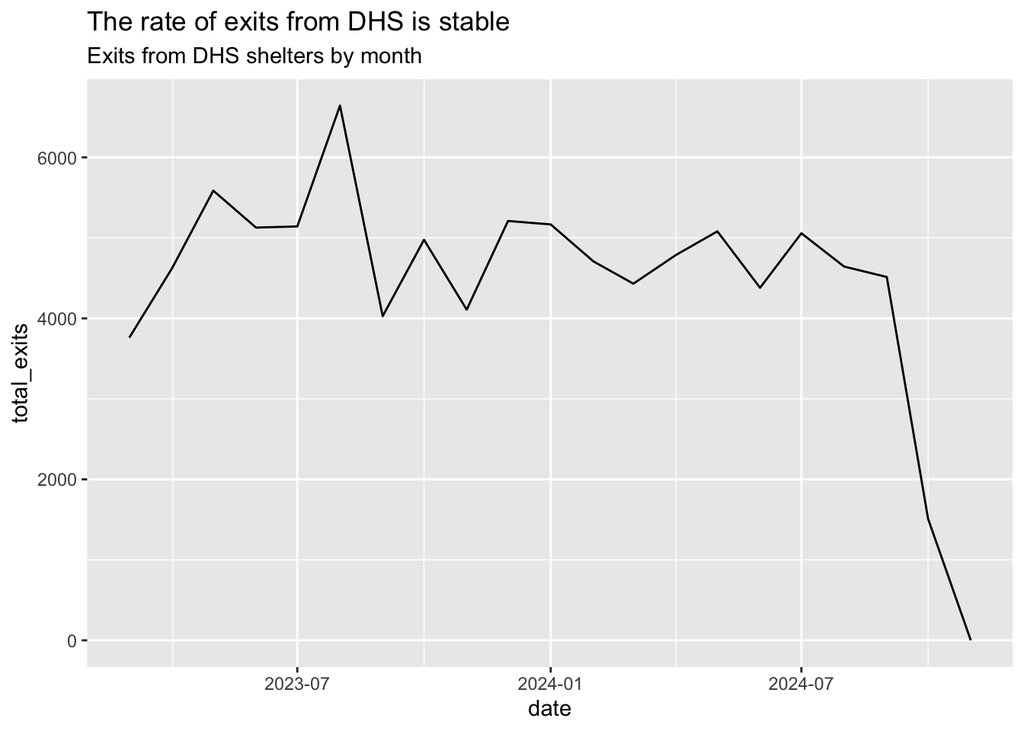

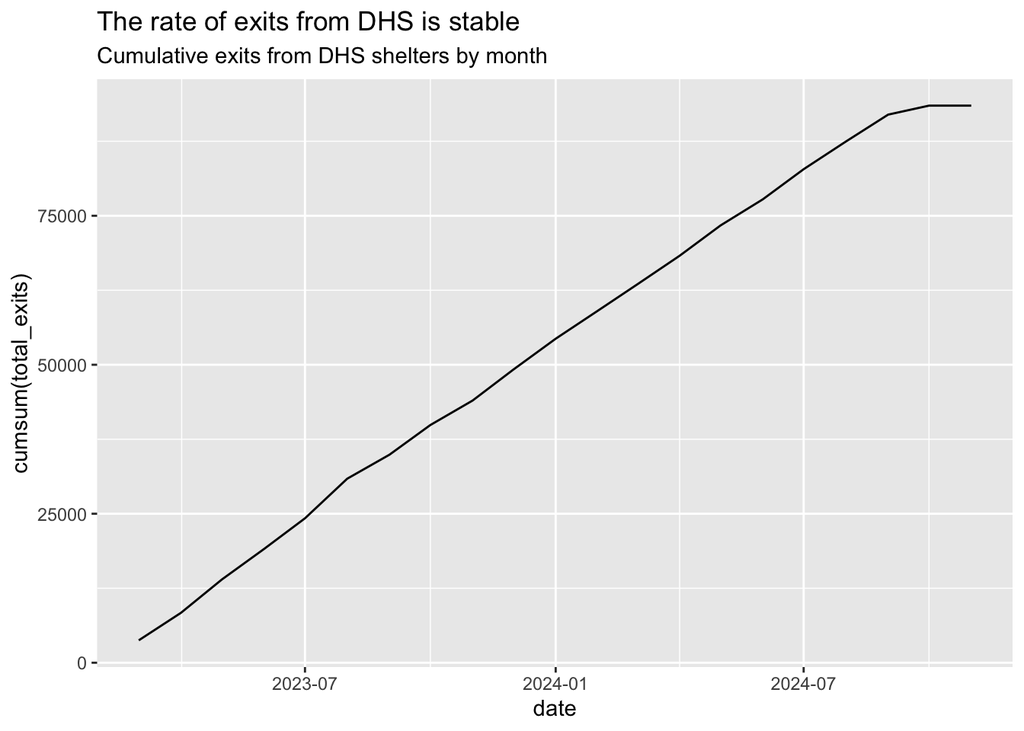

## Entrants

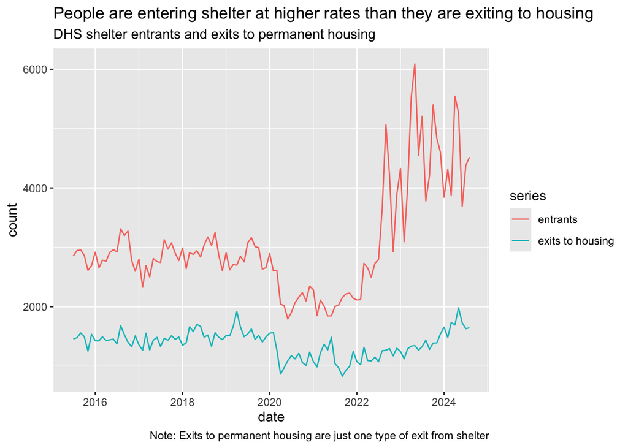

## Total exits by category

The large majority exiting are families with children or total_single adults

|  | category | adult_families | families_with_children | runaway_and_homeless_youth | total_single_adults | Total |
| --- | --- | --- | --- | --- | --- | --- |
| 1 | Affordable housing | 0 | 0 | 0 | 0 | 0 |
| 2 | City-financed homeless unit | 0 | 155 | 0 | 292 | 447 |
| 3 | Family or friends | 49 | 2532 | 0 | 1533 | 4114 |
| 4 | Medical care or rehabilitation facility | 0 | 0 | 0 | 838 | 838 |
| 5 | NYCHA | 0 | 983 | 0 | 0 | 983 |
| 6 | Other | 272 | 2489 | 0 | 11090 | 13851 |
| 7 | Private market | 20 | 1358 | 0 | 1299 | 2677 |
| 8 | Rapid re-housing | 0 | 0 | 0 | 0 | 0 |
| 9 | Supportive housing | 0 | 376 | 0 | 2336 | 2712 |
| 10 | Transitional housing | 0 | 0 | 0 | 0 | 0 |

[output cut: 3 more lines]

### Total exits by category, proportion of population

|  | category | adult_families | families_with_children | runaway_and_homeless_youth | total_single_adults |
| --- | --- | --- | --- | --- | --- |
| 1 | Affordable housing | 0 | 0 |  | 0 |
| 2 | City-financed homeless unit | 0 | 0.00742052853312907 |  | 0.004092042938423162 |
| 3 | Family or friends | 0.03970826580226904 | 0.1212179241669858 |  | 0.0214832254267216 |
| 4 | Medical care or rehabilitation facility | 0 | 0 |  | 0.01174360267944729 |
| 5 | NYCHA | 0 | 0.04706051321332823 |  | 0 |
| 6 | Other | 0.2204213938411669 | 0.1191593259287629 |  | 0.155413548586003 |
| 7 | Private market | 0.01620745542949757 | 0.06501340482573727 |  | 0.01820398553771126 |
| 8 | Rapid re-housing | 0 | 0 |  | 0 |
| 9 | Supportive housing | 0 | 0.01800076599004213 |  | 0.03273634350738529 |
| 10 | Transitional housing | 0 | 0 |  | 0 |

[output cut: 2 more lines]

## Total exits by agency

The huge majority of exits are from DHS

|  | agency | adult_families | families_with_children | runaway_and_homeless_youth | total_single_adults |
| --- | --- | --- | --- | --- | --- |
| 1 | DHS | 1234 | 20888 | 0 | 71358 |
| 2 | DYCD | 0 | 0 | 10 | 3137 |
| 3 | HPD | 11 | 6 | 0 | 22 |
| 4 | HRA | 684 | 3117 | 0 | 6486 |

# Monthly exits

Note: DHS adult families are delayed 2 months, single adults delayed 1 month

|  | date | total_single_adults | adult_families | families_with_children | runaway_and_homeless_youth | Total |
| --- | --- | --- | --- | --- | --- | --- |
| 1 | 2023-03-01 | 3760 |  |  |  | 3760 |
| 2 | 2023-04-01 | 3899 | 50 | 671 |  | 4620 |
| 3 | 2023-05-01 | 5309 | 137 | 876 | 0 | 6322 |
| 4 | 2023-06-01 | 4821 | 92 | 910 | 0 | 5823 |
| 5 | 2023-07-01 | 4676 | 111 | 1021 | 0 | 5808 |
| 6 | 2023-08-01 | 6022 | 178 | 1180 | 0 | 7380 |
| 7 | 2023-09-01 | 3517 | 63 | 1086 | 0 | 4666 |
| 8 | 2023-10-01 | 4428 | 56 | 1212 | 0 | 5696 |
| 9 | 2023-11-01 | 3538 | 66 | 1157 | 0 | 4761 |
| 10 | 2023-12-01 | 4523 | 57 | 1313 | 0 | 5893 |

[output cut: 12 more lines]

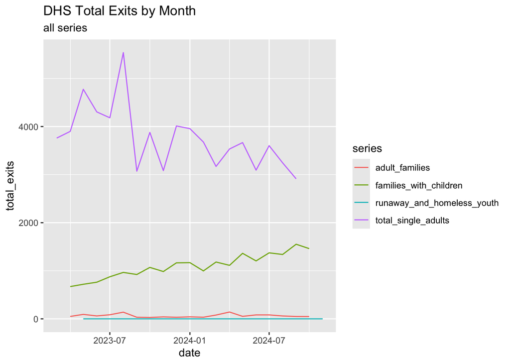

|  | housing_category | adult_families | families_with_children | runaway_and_homeless_youth | total_single_adults |
| --- | --- | --- | --- | --- | --- |
| 1 | Other | 0.2204213938411669 | 0.1191593259287629 |  | 0.1671571512654503 |
| 2 | Permanent Housing | 0.5518638573743923 | 0.6432880122558406 |  | 0.1863841475377673 |
| 3 | Unknown | 0.2277147487844408 | 0.2375526618153964 |  | 0.6464587011967824 |

## Families with children

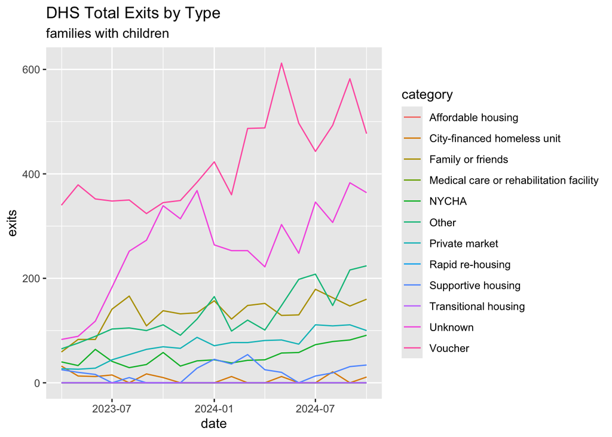

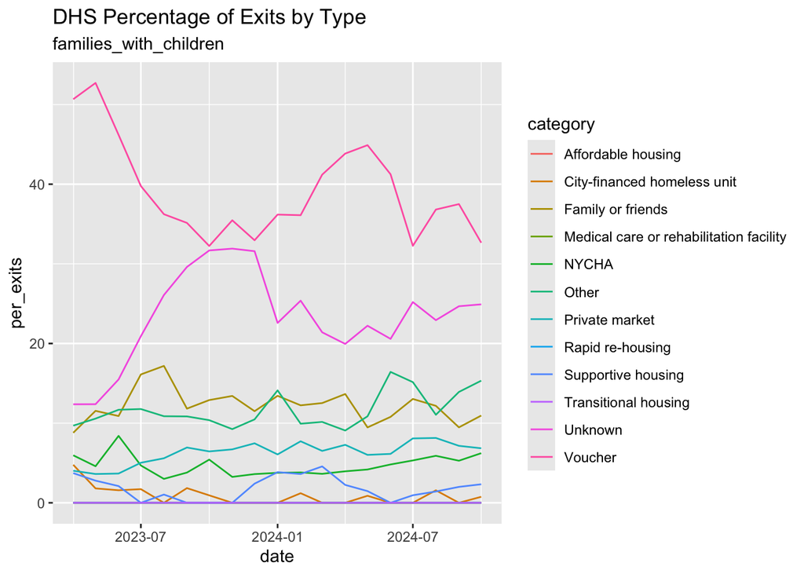

## Single Adults

A huge proportion of single adults exiting go to unknown places

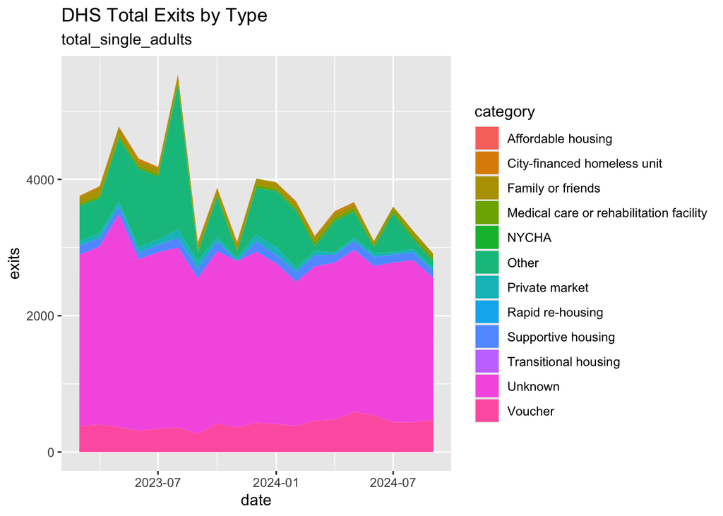

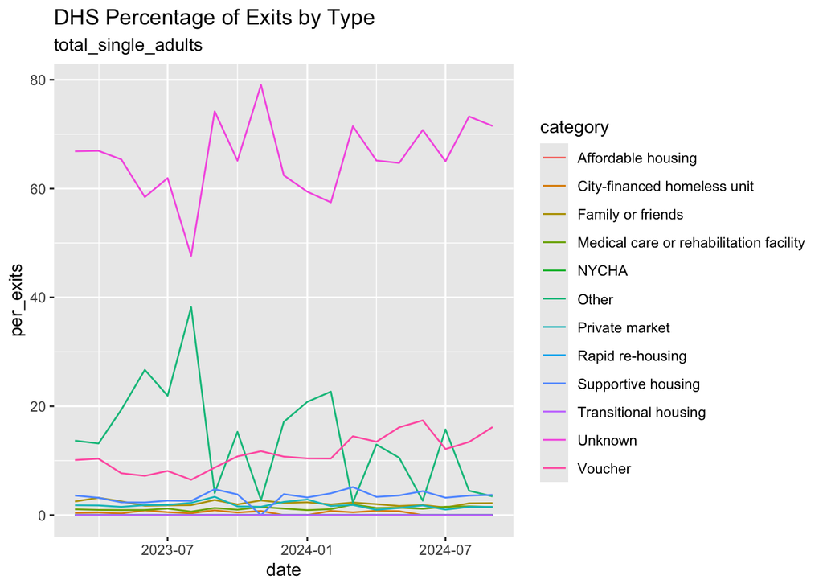

# Stats for Article

```
## [1] 0.1005774
```

```
## [1] 0.0257261
```

```
##                                 category        total
##                       Affordable housing 0.0000000000
##              City-financed homeless unit 0.0041794059
##                        Family or friends 0.0512935589
##                              Foster home 0.0000000000
##  Medical care or rehabilitation facility 0.0081344142
##                                    NYCHA 0.0091909530
##                                    Other 0.1319177583
##                            Other shelter 0.0034220639
##                           Private market 0.0285452488
##                         Rapid re-housing 0.0001121988
##                       Supportive housing 0.0301721317
##                     Transitional housing 0.0000000000
##                                  Unknown 0.5388348153
##                                  Voucher 0.1797986031
##                    Youth special program 0.0143988481
```

```
## # A tibble: 240 × 4
## # Groups:   date [20]
##    date       category                                   exits per_exits
##    <date>     <chr>                                      <dbl>     <dbl>
##  1 2023-03-01 Affordable housing                      0         0
##  2 2023-03-01 City-financed homeless unit             0.000160  0.000199
##  3 2023-03-01 Family or friends                       0.00101   0.00125
##  4 2023-03-01 Medical care or rehabilitation facility 0.000428  0.000532
##  5 2023-03-01 NYCHA                                   0         0
##  6 2023-03-01 Other                                   0.00550   0.00684
##  7 2023-03-01 Private market                          0.000727  0.000904
##  8 2023-03-01 Rapid re-housing                        0         0
##  9 2023-03-01 Supportive housing                      0.00144   0.00180
## 10 2023-03-01 Transitional housing                    0         0
## # ℹ 230 more rows
```

```
## # A tibble: 12 × 2
##    category                                total
##    <chr>                                   <dbl>
##  1 Affordable housing                          0
##  2 City-financed homeless unit               447
##  3 Family or friends                        4114
##  4 Medical care or rehabilitation facility   838
##  5 NYCHA                                     983
##  6 Other                                   13851
##  7 Private market                           2677
##  8 Rapid re-housing                            0
##  9 Supportive housing                       2712
## 10 Transitional housing                        0
## 11 Unknown                                 51373
## 12 Voucher                                 16485
```

```
##                                 category       total
##                       Affordable housing 0.000000000
##              City-financed homeless unit 0.004781772
##                        Family or friends 0.044009414
##  Medical care or rehabilitation facility 0.008964484
##                                    NYCHA 0.010515618
##                                    Other 0.148170732
##                           Private market 0.028637142
##                         Rapid re-housing 0.000000000
##                       Supportive housing 0.029011553
##                     Transitional housing 0.000000000
##                                  Unknown 0.549561404
##                                  Voucher 0.176347882
```

```
##                                 category       total
##                       Affordable housing 0.000000000
##              City-financed homeless unit 0.004781772
##                        Family or friends 0.044009414
##  Medical care or rehabilitation facility 0.008964484
##                                    NYCHA 0.010515618
##                                    Other 0.148170732
##                           Private market 0.028637142
##                         Rapid re-housing 0.000000000
##                       Supportive housing 0.029011553
##                     Transitional housing 0.000000000
##                                  Unknown 0.549561404
##                                  Voucher 0.176347882
```